# Projekt Analiza Danych

A. Kierznikowicz, J. Dobosz, P. Cebulska

2024-11-20

## 1. Wczytanie danych

## 2. Porządkowanie danych

W pierwszej części projektu analizujemy dane źródłowe pod kątem wystąpienia **braków danych**.

## a) Wstępne rozeznanie

```
##    Loan_ID Gender Married Dependents    Education Self_Employed ApplicantIncome
## 1 LP001015   Male     Yes          0     Graduate            No            5720
## 2 LP001022   Male     Yes          1     Graduate            No            3076
## 3 LP001031   Male     Yes          2     Graduate            No            5000
## 4 LP001035   Male     Yes          2     Graduate            No            2340
## 5 LP001051   Male      No          0 Not Graduate            No            3276
## 6 LP001054   Male     Yes          0 Not Graduate           Yes            2165
##   CoapplicantIncome LoanAmount Loan_Amount_Term Credit_History Property_Area
## 1                 0        110              360              1         Urban
## 2              1500        126              360              1         Urban
## 3              1800        208              360              1         Urban
## 4              2546        100              360             NA         Urban
## 5                 0         78              360              1         Urban
## 6              3422        152              360              1         Urban
```

## b) Sprawdzanie braków danych

```
## [1] 40
```

## c) Sprawdzanie czy są puste komórki

```
## [1] 44
```

## d) zsumowanie pustych komórek i komórek NA

```
## [1] 84
```

Z powyższej analizy wynika, że wśród danych źródłowych znjaduje się **40** wartości oznaczonych jako NA oraz **44** zmienne puste. W związu z tym należy przekodować zmienne tak, aby w miejsce pustych komórek pojawiły się wartości NA.

## 3. Przekodowanie zmiennych

Na początek zmienne kategoryczne zostają przekodowane na zmienne numeryczne, aby możliwe było zbadanie koralecji pomiędzy poszczególnymi zmiennymi oraz aby zapobiec pojawianiu się pustych komórek.

**opis przekształceń poszczególnych zmiennych kategorycznych do postaci numerycznej**

**Gender:** Zmienna Gender zawiera informacje o płci, “Male” jest kodowana jako 1, a “Female” 0.

**Married:** Zmienna Married jest przekodowywana, aby 1 oznaczało “Yes”,a 0 “No”.

**Self_Employed:** Zmienna Self_Employed jest przekodowywana na 1 dla odpowiedzi “Yes”, a 0 dla “No”.

**Education:** Wartości “Graduate” są kodowane jako 1, a “Not Graduate” jako 0

**Property_Area:** Zmienna Property_Area zawiera trzy kategorie: “Rural”, “Semiurban”, “Urban”. Zostały im przypisane kolejno liczby: 1, 2 i 3.

**Dependents:** Zmienna Dependents zawiera liczbę osób na utrzymaniu, wartość “3+” jest zamieniana na 3, a pozostałe wartości są przekodowane na liczby.

## a) Następnie sprawdzamy jak wyglądają zmienne po przekodowaniu.

```
##   Gender Married Dependents Education Self_Employed ApplicantIncome
## 1      1       1          0         1             0            5720
## 2      1       1          1         1             0            3076
## 3      1       1          2         1             0            5000
## 4      1       1          2         1             0            2340
## 5      1       0          0         0             0            3276
## 6      1       1          0         0             1            2165
##   CoapplicantIncome LoanAmount Loan_Amount_Term Credit_History Property_Area
## 1                 0        110              360              1             3
## 2              1500        126              360              1             3
## 3              1800        208              360              1             3
## 4              2546        100              360             NA             3
## 5                 0         78              360              1             3
## 6              3422        152              360              1             3
```

## b) Sprawdzanie czy są puste komórki

```
## [1] 0
```

W wyniku przekodowania zmiennych zniwelowane zostały puste komórki, które przyjęły teraz postać NA.

## c) Sprawdzanie braków danych

```
## [1] 84
```

Ostatecznie w danych znajdują się **84** braki danych oznaczone jako NA.

## d) Zmieniamy zmienne po przekodowaniu na numeryczne.

## 4. Analiza braków danych

## a) Macierz korelacji poszczególnych zmiennych

Następnie tworzymy macierz korelacji wszystkich zmiennych.

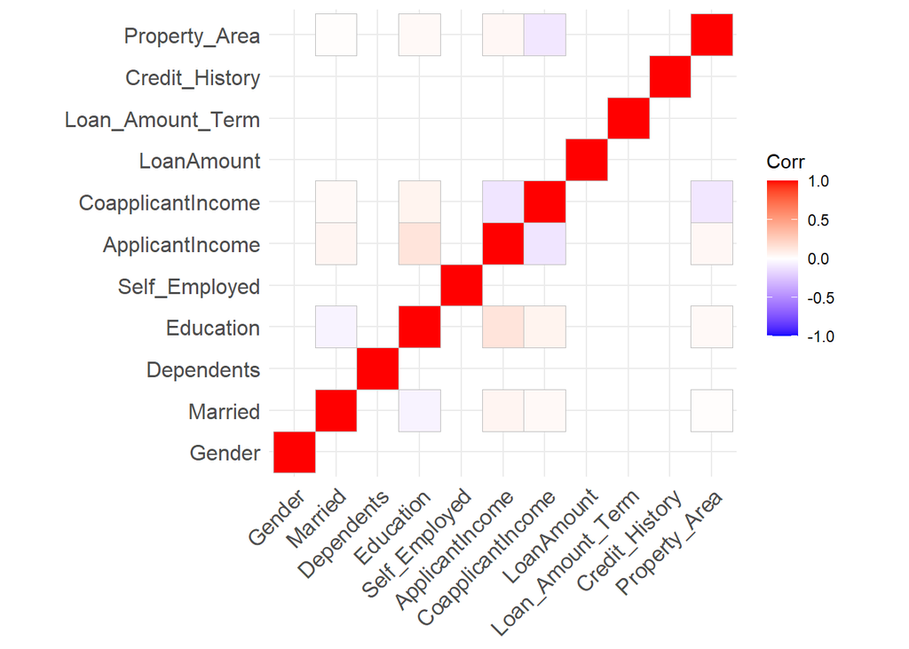

Macierz korelacji przedstawia zależności pomiędzy wszystkimi zmiennymi, umożliwiając wstępną ocenę, które zmienne i w jakim stopniu są ze sobą skorelowane.

## b) Graficzna analiza braków danych

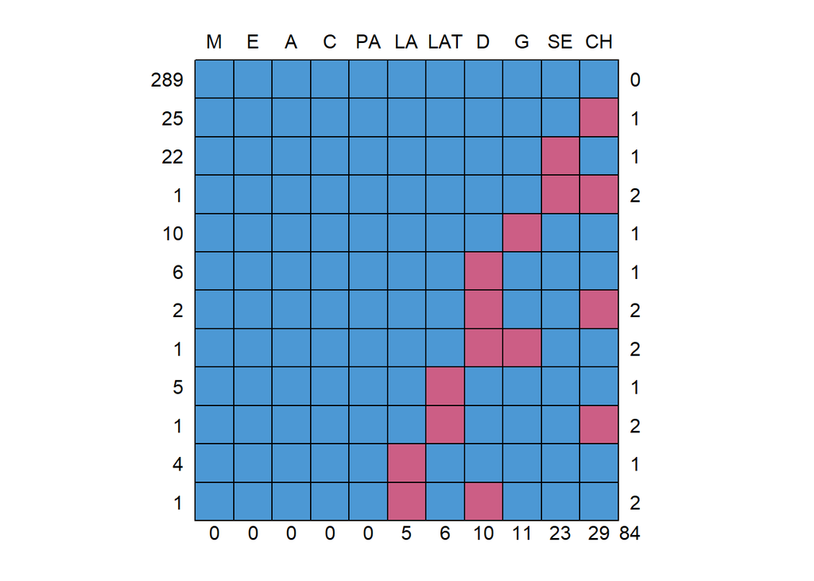

```
##     M E A C PA LA LAT  D  G SE CH
## 289 1 1 1 1  1  1   1  1  1  1  1  0
## 25  1 1 1 1  1  1   1  1  1  1  0  1
## 22  1 1 1 1  1  1   1  1  1  0  1  1
## 1   1 1 1 1  1  1   1  1  1  0  0  2
## 10  1 1 1 1  1  1   1  1  0  1  1  1
## 6   1 1 1 1  1  1   1  0  1  1  1  1
## 2   1 1 1 1  1  1   1  0  1  1  0  2
## 1   1 1 1 1  1  1   1  0  0  1  1  2
## 5   1 1 1 1  1  1   0  1  1  1  1  1
## 1   1 1 1 1  1  1   0  1  1  1  0  2
## 4   1 1 1 1  1  0   1  1  1  1  1  1
## 1   1 1 1 1  1  0   1  0  1  1  1  2
##     0 0 0 0  0  5   6 10 11 23 29 84
```

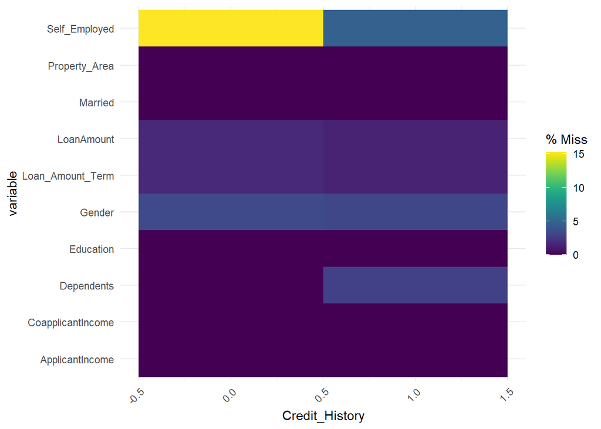

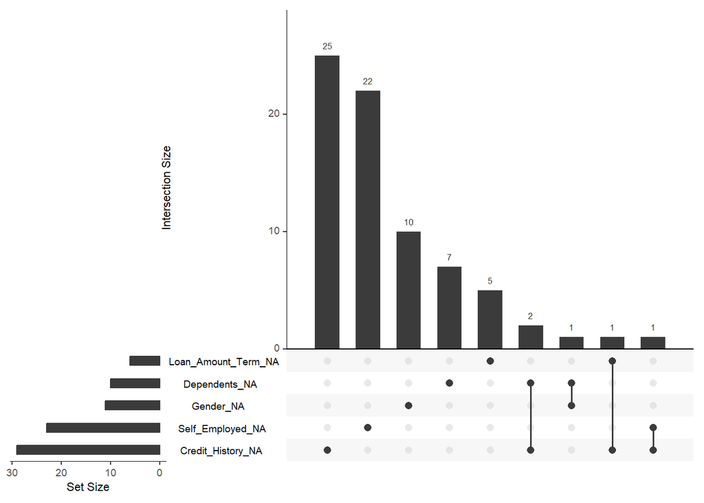

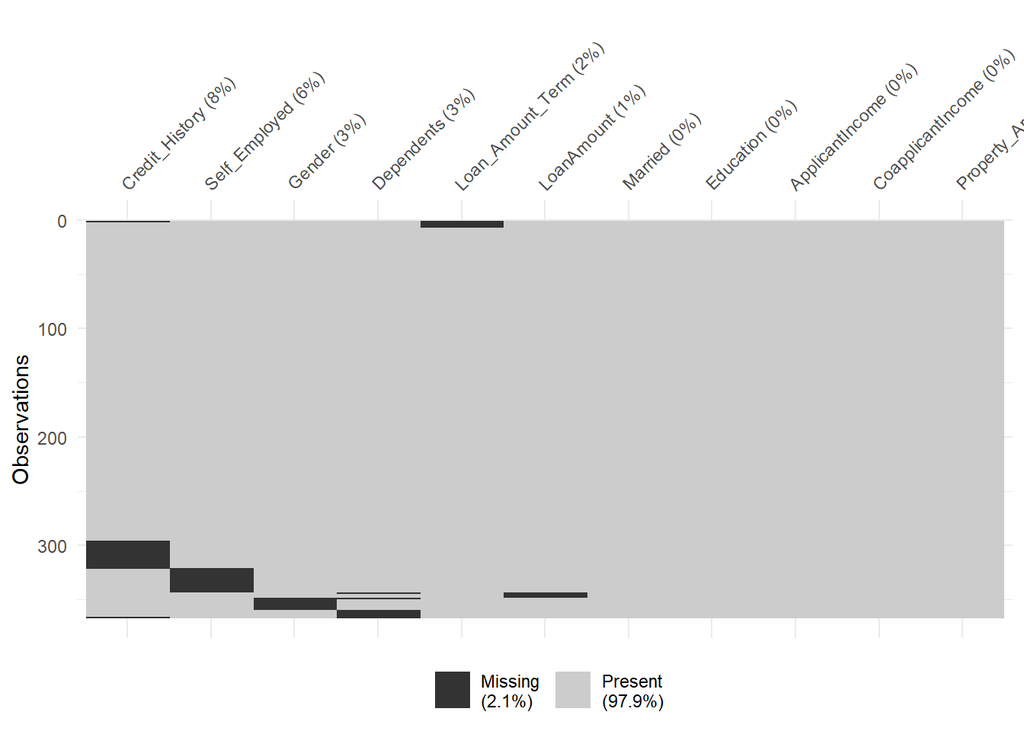

## 5. WNIOSKI

Pierwszy z efektów analizy to **macierz wzorców braków danych**, która przedstawia unikalne wzorce braków danych dla poszczególnych zmiennych. Komórki z brakami są zaznaczone w tabeli na różowo, co pozwala zrozumieć, które zmienne i jak często mają braki. Pierwszy wiersz (289 obserwacji) nie ma żadnych braków danych. Oznacza to, że większość danych jest kompletna. Natomiast W pozostałych wierszach widzimy różne wzorce braków. Na przykład w drugim wierszu 25 obserwacji ma braki w zmiennej CH. Z kolei zmienna CH ma 29 braków.

Na koniec zbudowano **mapę cieni**, która przedstawia procentowy udział braków danych w całości analizowanych danych. W analizowanym przypadku braki danych stanowią 2,1% zmiennych, z czego największy udział mają braki w kolumnie Credit_History (8%), a najmniejszy - LoanAmount (1%).

## Test statystyczny braków danych

```
## # A tibble: 1 × 4
##   statistic    df p.value missing.patterns
##       <dbl> <dbl>   <dbl>            <int>
## 1      73.4   105   0.992               12
```

Hipoteza zerowa testu: Braki danych są MCAR (całkowicie losowe). Hipoteza alternatywna testu: Braki danych nie są MCAR.

*Wartość p (0.9918873) jest znacznie większa niż próg istotności (0.05)*, więc nie ma podstaw do odrzucenia hipotezy zerowej. Oznacza to, że braki w analizowanych danych są całkowicie losowe i nie zależą od wartości innych zmiennych ani samych brakujących danych. Co więcej, istnienie *12 wzorców braków danych* sugeruje, że różne obserwacje mają różne kombinacje braków.

Ponadto obserwowany niski poziom korelacji pomiędzy zmiennymi oraz analiza powyższych wykresów wskazuje na to, że braki danych należy skategoryzować jako MCAR (Całkowicie losowe braki danych).

## 6. Analiza odchyleń

## a) Obserwacje odstające - jednowymiarowe - Boxplot

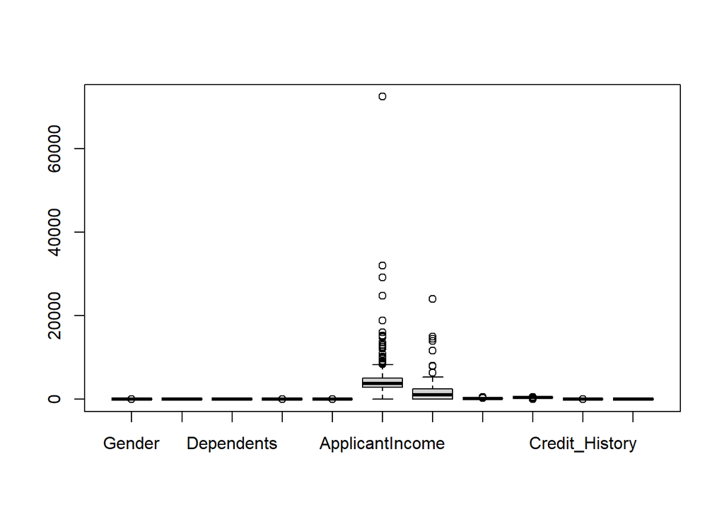

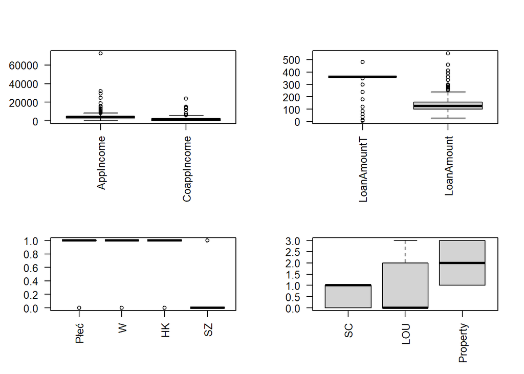

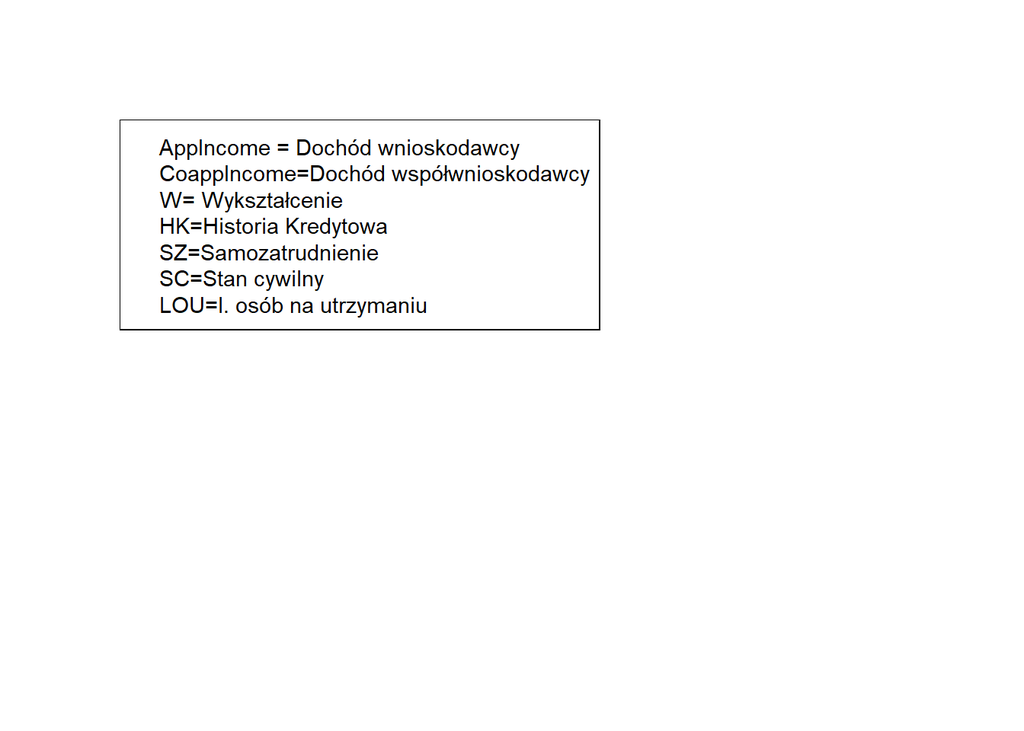

```
##     Gender Married Dependents Education Self_Employed ApplicantIncome
## 7        0       0          1         0             0            2226
## 15       0       0          0         1             0            4666
## 22       0       0          3         0             0            2083
## 24       0       0          0         0             0            3765
## 31       0       0          0         0             0            2478
## 42       0       0          0         1             0            3644
## 45       0       0          0         1             0            3666
## 57       0       0          0         0             0            4402
## 59       0       1          2         1             0            2779
## 63       0       0          2         1             0            4968
## 64       0       0          0         1             0            2101
## 71       0       0         NA         1             0            3250
## 80       0       1          0         1             0            7950
## 90       0       0          0         1            NA            5058
```

[output cut: 127 more lines]

```
##      Gender          Married         Dependents       Education
##  Min.   :0.0000   Min.   :0.0000   Min.   :0.0000   Min.   :0.0000
##  1st Qu.:1.0000   1st Qu.:0.0000   1st Qu.:0.0000   1st Qu.:0.1000
##  Median :1.0000   Median :1.0000   Median :0.0000   Median :1.0000
##  Mean   :0.8034   Mean   :0.5711   Mean   :0.7207   Mean   :0.6338
##  3rd Qu.:1.0000   3rd Qu.:1.0000   3rd Qu.:1.0000   3rd Qu.:1.0000
##  Max.   :1.0000   Max.   :1.0000   Max.   :3.0000   Max.   :1.0000
##  NA's   :11                        NA's   :10
##  Self_Employed    ApplicantIncome CoapplicantIncome   LoanAmount
##  Min.   :0.0000   Min.   :    0   Min.   :    0     Min.   : 28.0
##  1st Qu.:0.0000   1st Qu.: 2864   1st Qu.:    0     1st Qu.:100.2
##  Median :0.0000   Median : 3786   Median : 1025     Median :125.0
##  Mean   :0.1076   Mean   : 4806   Mean   : 1570     Mean   :136.1
##  3rd Qu.:0.0000   3rd Qu.: 5060   3rd Qu.: 2430     3rd Qu.:158.0
##  Max.   :1.0000   Max.   :72529   Max.   :24000     Max.   :550.0
##  NA's   :23                                         NA's   :5
##  Loan_Amount_Term Credit_History   Property_Area
##  Min.   :  6.0    Min.   :0.0000   Min.   :1.000
##  1st Qu.:360.0    1st Qu.:1.0000   1st Qu.:1.000
##  Median :360.0    Median :1.0000   Median :2.000
##  Mean   :342.5    Mean   :0.8254   Mean   :2.079
##  3rd Qu.:360.0    3rd Qu.:1.0000   3rd Qu.:3.000
##  Max.   :480.0    Max.   :1.0000   Max.   :3.000
##  NA's   :6        NA's   :29
```

## b) Obserwacje odstające - wielowymiarowe - Scatterplot

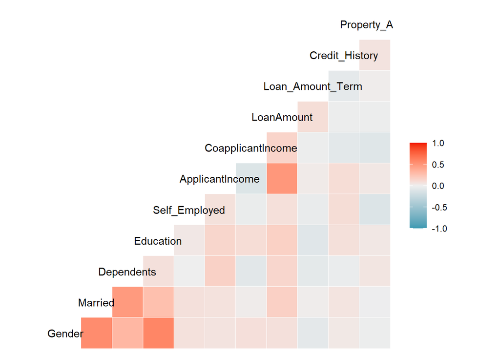

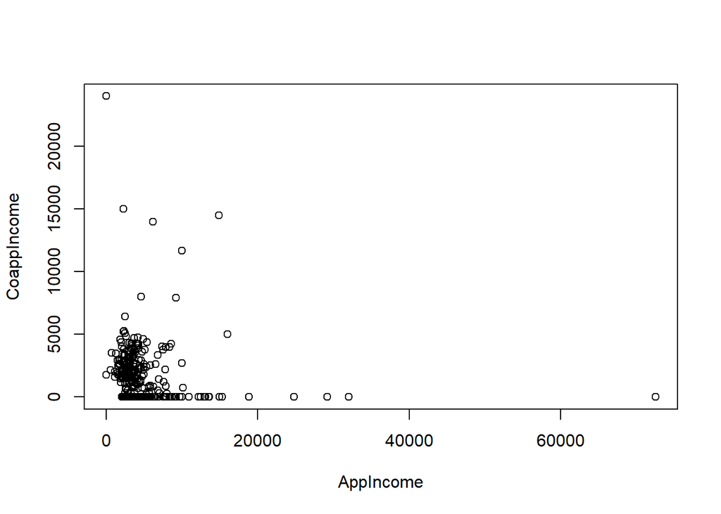

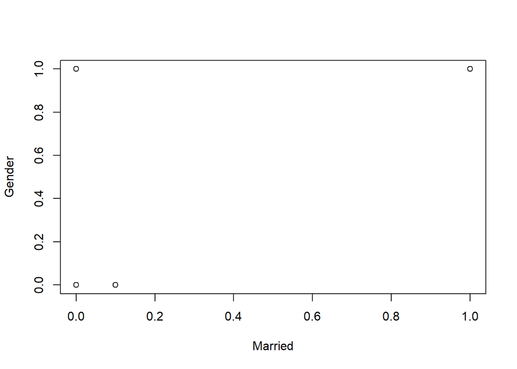

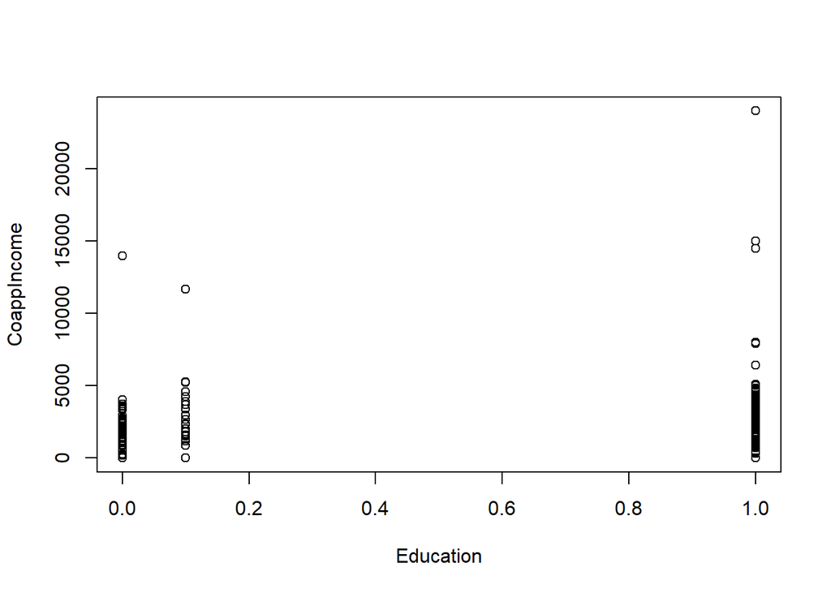

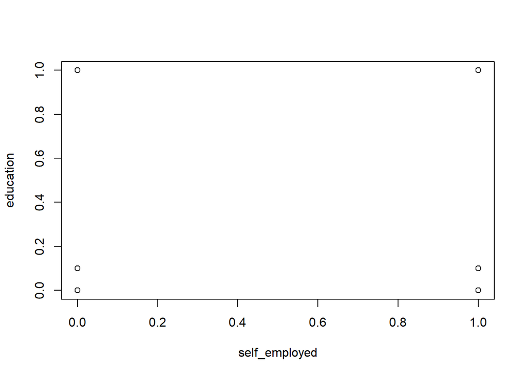

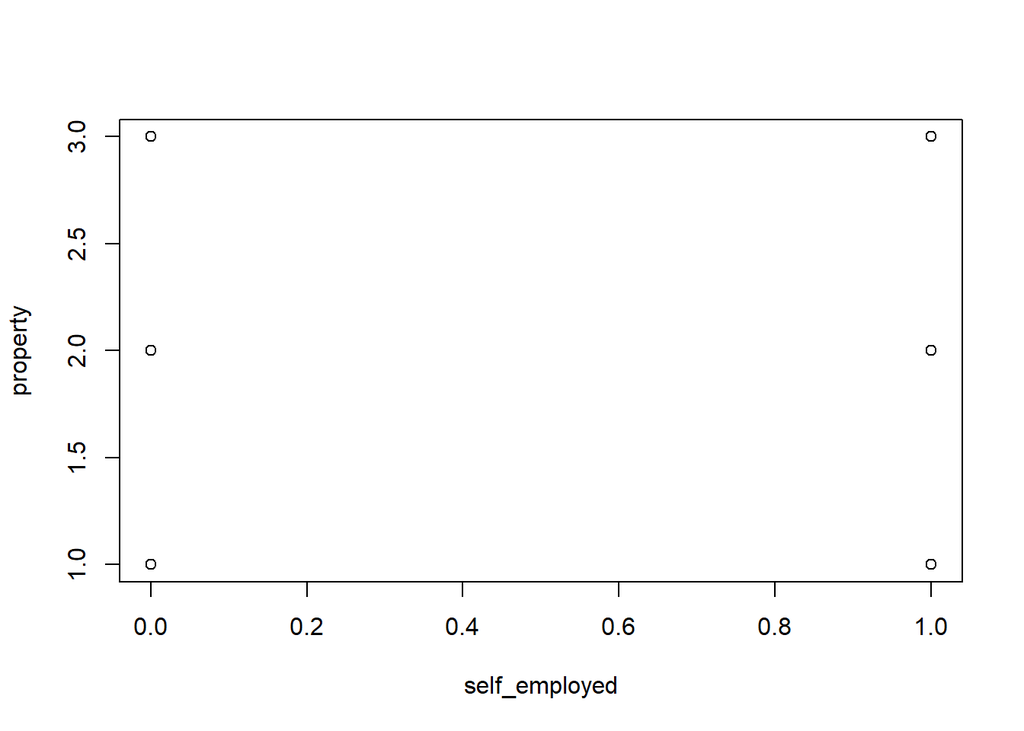

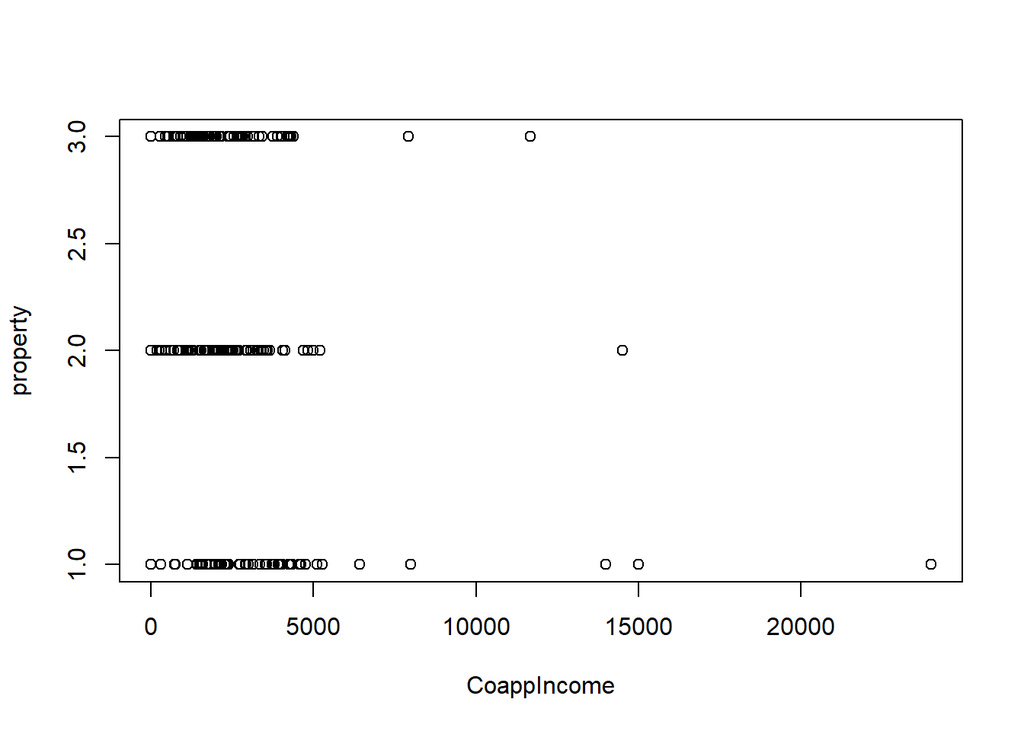

## c) Metoda kwantyl-kwantyl

Stworzono wykresy typu Q-Q dla zmiennych, dla których zidentyfikowano wartości odchylające się podczas analizy wykresami pudełkowymi

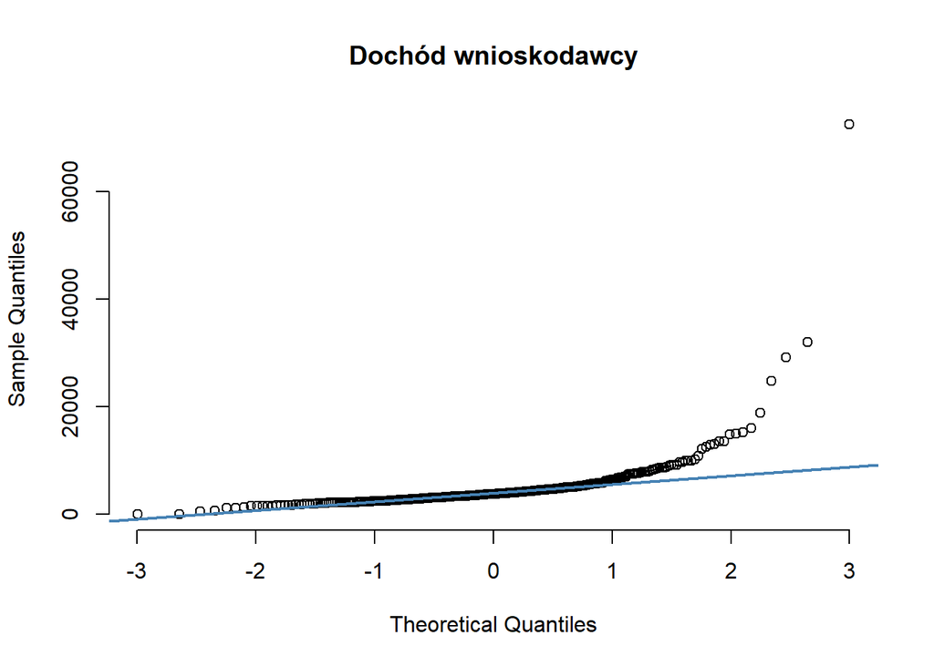

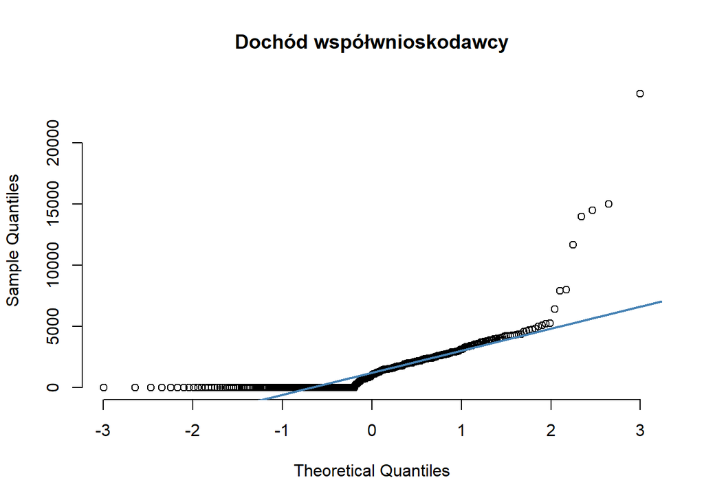

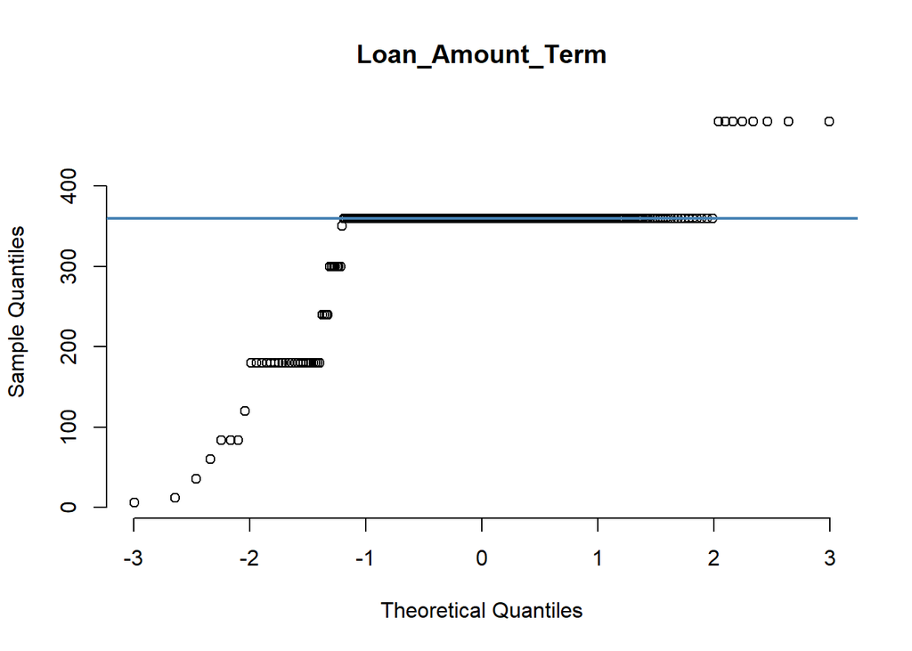

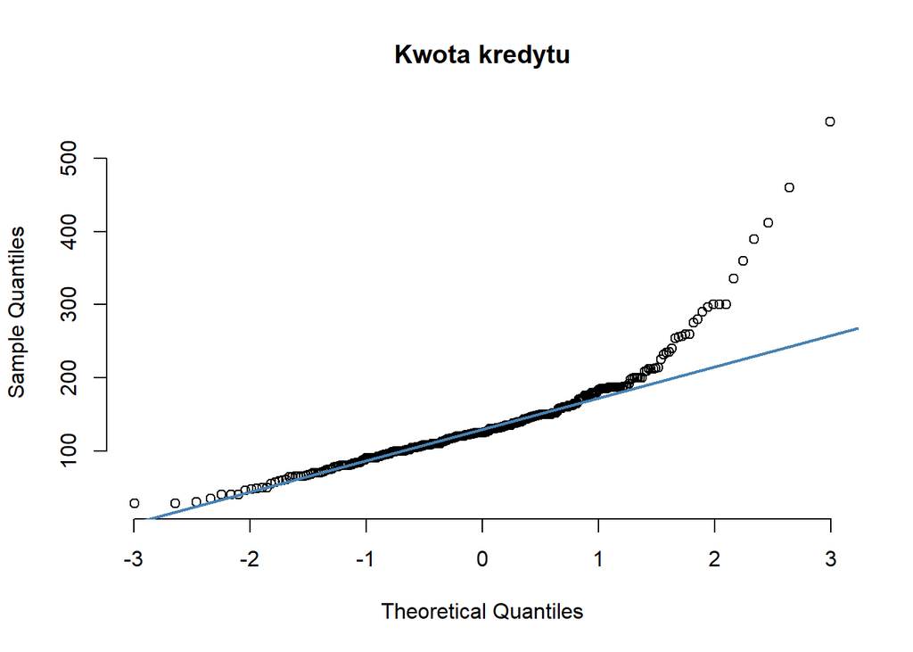

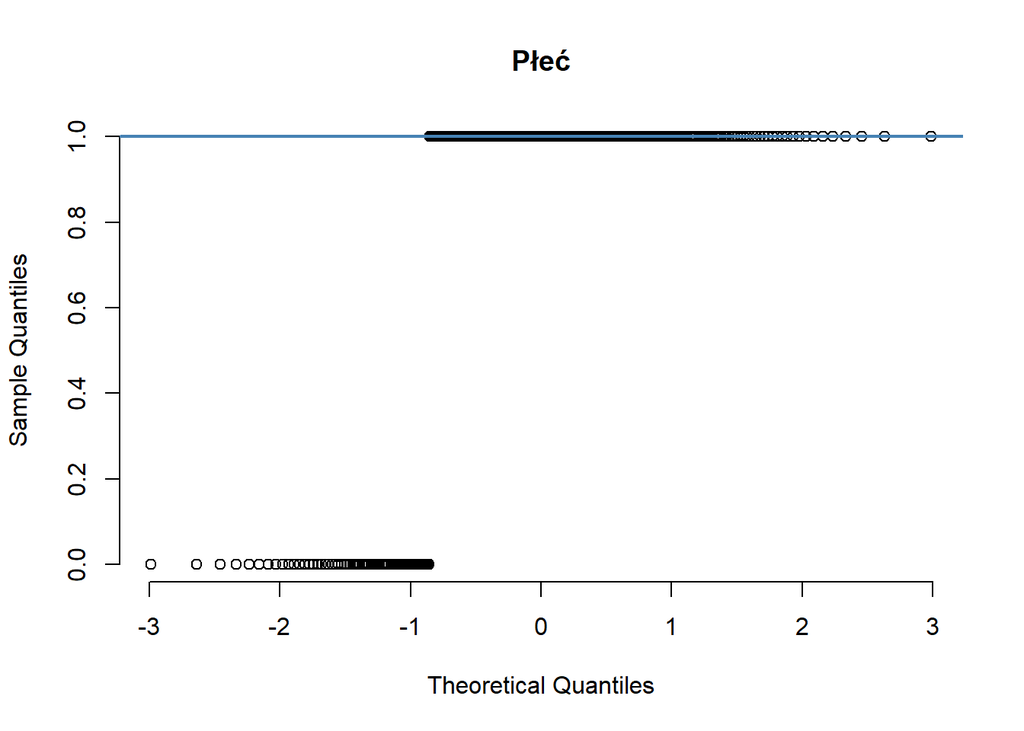

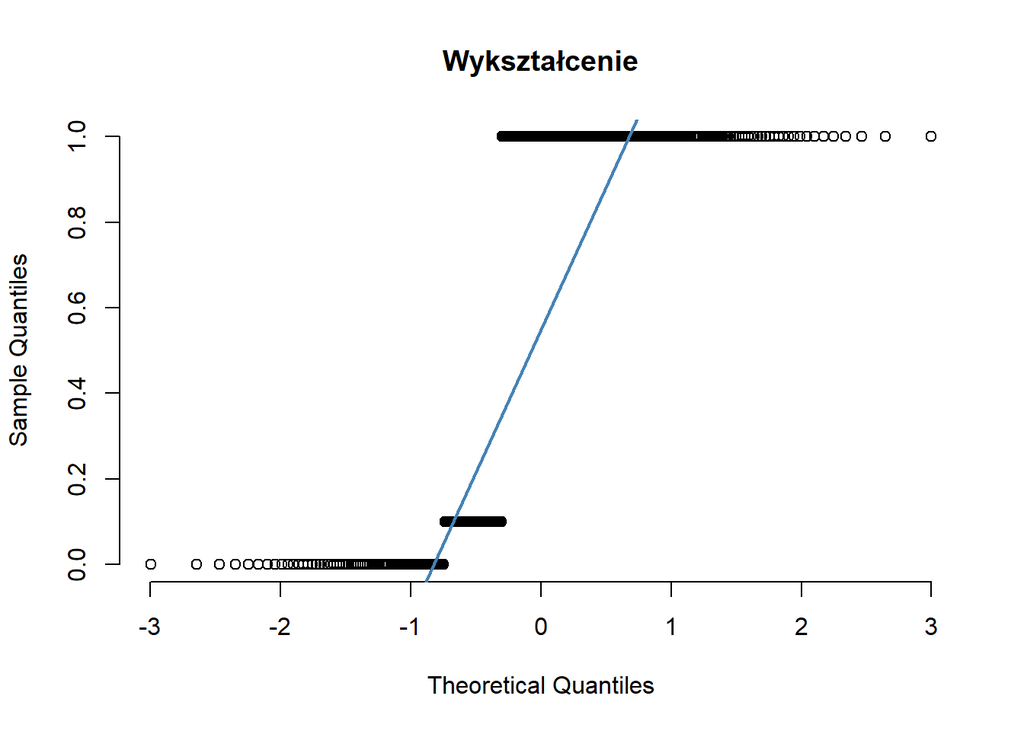

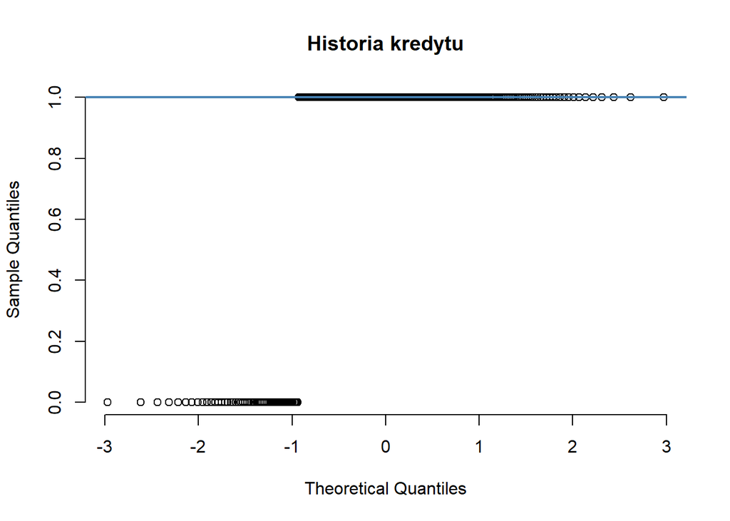

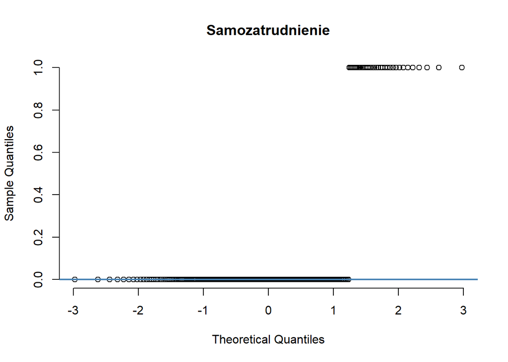

## d) Odchylenia Cook’a

[output not shown]

[output cut: 67 more lines]

[output not shown]

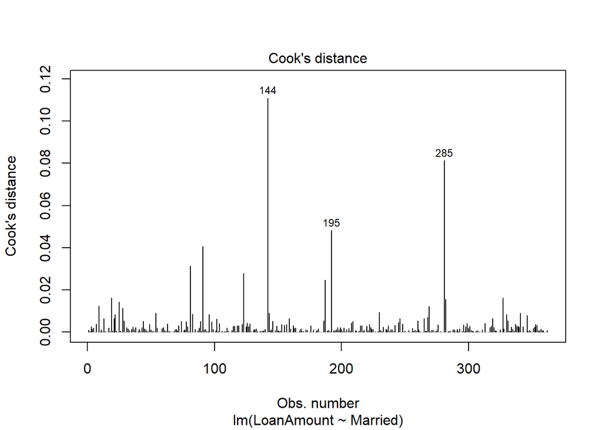

[output not shown]

[output cut: 63 more lines]

[output not shown]

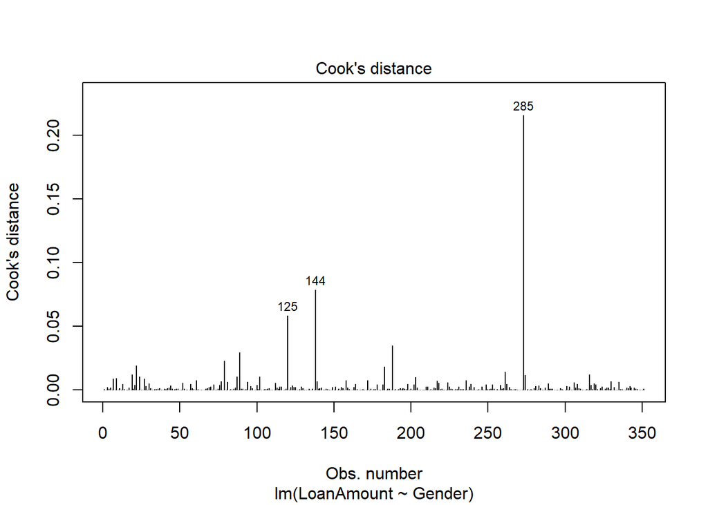

[output not shown]

[output cut: 67 more lines]

[output not shown]

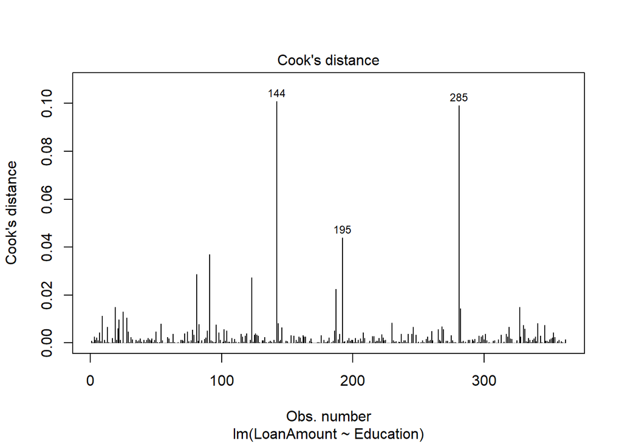

[output not shown]

[output cut: 67 more lines]

[output not shown]

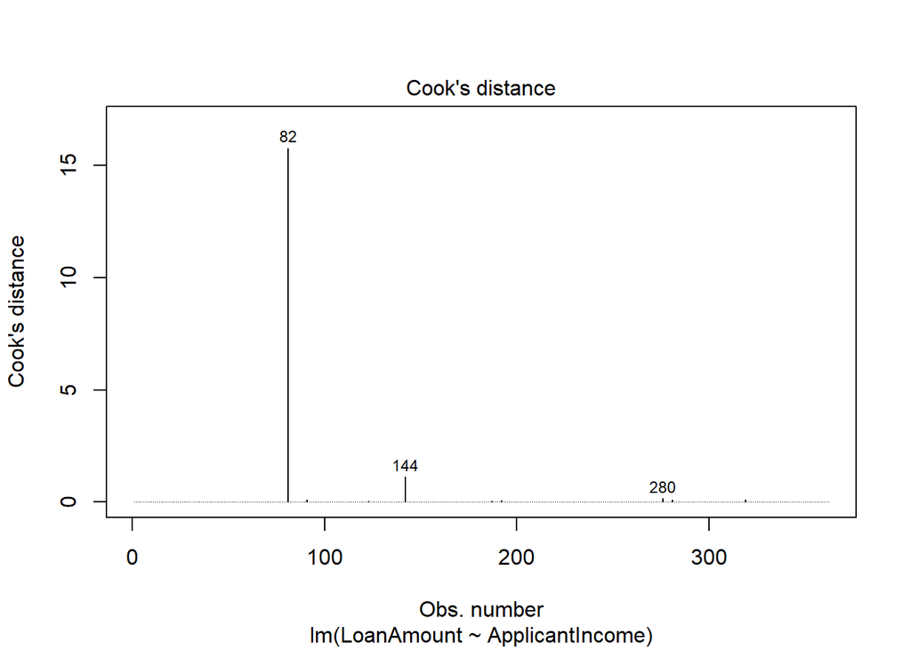

[output not shown]

[output cut: 65 more lines]

[output not shown]

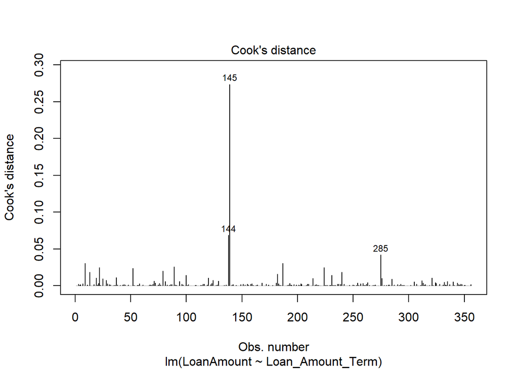

## 7. Imputacja brakujących danych

*1. Funkcja licząca dominantę*

*2. Zastosowanie funkcji na wszystkich kolumnach*

```
##   Gender Married Dependents Education Self_Employed ApplicantIncome
## 1      1       1          0         1             0            3500
##   CoapplicantIncome LoanAmount Loan_Amount_Term Credit_History Property_Area
## 1                 0        150              360              1             3
```

*3. Zastąpienie braków danych dominantą*

*4. Sprawdzenie, czy wszystkie braki danych zostały zastąpione*

```
##  /\     /\
## {  `---'  }
## {  O   O  }
## ==>  V <==  No need for mice. This data set is completely observed.
##  \  \|/  /
##   `-----'
```

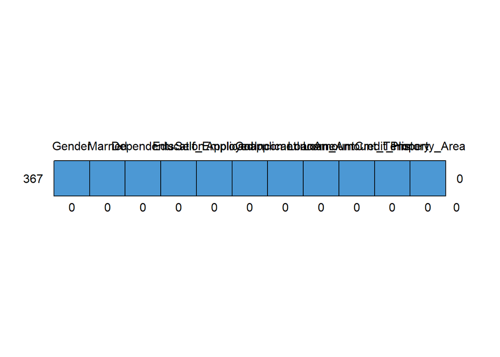

```
##     Gender Married Dependents Education Self_Employed ApplicantIncome
## 367      1       1          1         1             1               1
##          0       0          0         0             0               0
##     CoapplicantIncome LoanAmount Loan_Amount_Term Credit_History Property_Area
## 367                 1          1                1              1             1
##                     0          0                0              0             0
##
## 367 0
##     0
```

## b) Imputacja brakujących danych metodą KNN - K-najbliższych sąsiadów

```
## VIM is ready to use.
```

```
## Suggestions and bug-reports can be submitted at: https://github.com/statistikat/VIM/issues
```

Brakujące dane zostały uzupełnione za pomocą 5 najbliższych sąsiednich wartości. (k = 5) Ponowne sprawdzenie czy istnieją braki po imputacji.

```
## [1] 0
```

## c) Wielowymiarowe wypełnianie braków danych przez równania łańcuchowe

Do imputacji braków w danych użyto pakietu **mice** (Multivariate Imputation by Chained Equations), stosując metodę **pmm** (Predictive Mean Matching), która wypełniała braki na podstawie podobnych obserwacji z danych.

Zimputowane zostały brakujące obserwacje w zmiennej **Gender**, a następnie uzupełniono brakujące wartości w zbiorze danych.

Proces ten został powtórzony dla pozostałych zmiennych

**zmienna Dependents**

**zmienna Self_Employed**

**zmienna LoanAmount**

**zmienna Loan_Amount_Term**

**zmienna Credit_History**

Proces został wykonany dla każdej zmiennej z brakami (Gender, Dependents, Self_Employed, LoanAmount, Loan_Amount_Term, Credit_History) i polegał na imputacji tych braków w konkretnej zmiennej na podstawie podobnych obserwacji z danych.

Sprawdzenie czy wszystkie braki zostały uzupełnione.

```
## [1] 0
```

## d) Imputacja brakujących danych metodą hot-deck

…… Jeszcze raz sprawdzam, czy zostały zapełnione wszystkie komórki z NA

```
##  /\     /\
## {  `---'  }
## {  O   O  }
## ==>  V <==  No need for mice. This data set is completely observed.
##  \  \|/  /
##   `-----'
```

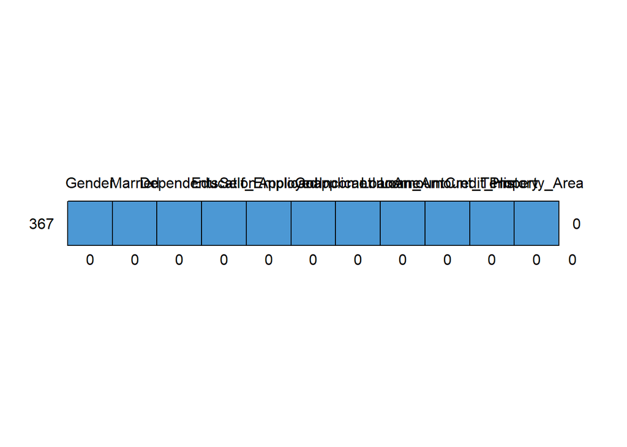

```
##     Gender Married Dependents Education Self_Employed ApplicantIncome
## 367      1       1          1         1             1               1
##          0       0          0         0             0               0
##     CoapplicantIncome LoanAmount Loan_Amount_Term Credit_History Property_Area
## 367                 1          1                1              1             1
##                     0          0                0              0             0
##
## 367 0
##     0
```